# Projekt2

Estera Saidło

5 czerwca 2019

# 1 Wstęp

Przed udzieleniem kredytu bank weryfikuje wiarygodność podmiotu ubiegającego się o kredyt. Scoring kredytowy jest metodą, która tę wiarygodność sprawdza. Ocena scoringowa polega na określeniu wiarygodności kredytowej klienta na podstawie porównania jego profilu z profilem klientów, którzy już otrzymali kredyty. Im większe podobieństwo profilu wnioskodawcy do osoby, która otrzymała kredyt tym większa szansa na jego otrzymanie. Niniejszy projekt jest poświęcony budowie modelu scoringowego, który będzie przewidywał czy wnioskodawca otrzyma kredyt czy też nie.

Do budowy modelu zostaną użyte takie metody jak:

- regresja logistyczna,
- Bagging,
- Boosting,
- Random Forest,
- Naive Bayes.

Metody postępowania z outlierami użyte w projekcie:

- usunięcie,
- zastąpienie NA i prognozowanie ich za pomocą metody k-najbliższych sąsiadów.

Metody postępowania z wartościami brakującymi użyte w projekcie:

- usunięcie,
- prognozowanie metodą k-najbliższych sąsiadów.

## 1.1 Opis użytych metod

### 1.1.1 regresja logistyczna

Regresja logistyczna służy do badania wpływu niezależnych zmiennych objaśniających ${x_1,…,x_n}$ na zmienną objaśnianą jakościową. Zmienna objaśniana najczęściej przyjmuje dwie wartości:

- 1 – rozważana sytuacja będzie miała miejsce;
- 0 – rozważana sytuacja nie będzie miała miejsca.

Wynik regresji logistycznej wyraża prawdopodobieństwo zajścia pewnego zdarzenia i przyjmuje wartość z przedziału 0-1. Aby zaklasyfikować obserwację do konkretnego scenariusza, ustala się tzw. próg odcięcia (ang.: cut off ). Na przykład $P(Y=1|X)>0.5$ oznacza, że jeżeli prawdopodobieństwo, że zmienna $Y$ przyjmie wartość 1 jest większe niż 50%, pod warunkiem zajścia zdarzenia $X$, zmiennej $Y$ zostanie przypisana wartość 1, w przeciwnym razie 0.

### 1.1.2 Bagging

Jest to metoda agregacji bootstrapowej o architekturze równoległej - opiera się na wylosowaniu ze zwracaniem n-elementowych prób uczących $U_1,…,U_v$ ze zbioru treningowego $U$ i budowie $V$ modeli wyjściowych. Na podstawie każdej próby budowany jest model $D_i$, gdzie $i∈1,…,v$ . Do stworzenia modelu zagregowanego $D^*$używana jest funkcja agregacji $ψ$. Największą zaletą tej metody jest redukcja wariancji modeli wyjściowych.

### 1.1.3 Boosting

Jest to metoda agregacji oparta na architekturze szeregowej. Polega na poprawieniu dokładności predykcji modelu $D^*$ przez modyfikowanie słabych modeli wyjściowych. Opiera się to na wykorzystaniu podwójnego systemu wag. W pierwszym systemie obserwacje, które zostały zaklasyfikowane niepoprawnie otrzymują wyższe wagi, drugi natomiast nawiązuje do modeli wyjściowych – każdy model otrzymuje wagę proporcjonalną do jego błędu predykcji. Wagi modeli mniej precyzyjnych zostają zmniejszone, zaś tych lepszych zwiększone.

### 1.1.4 Random Forest

Jest to metoda, która polega na tym, że oprócz bootstrapowego losowania obserwacji do prób uczących $U_1,…,U_v$(Bagging), wykorzystuje się również losowy dobór zmiennych do modeli wyjściowych $D_1,…,D_v$.

### 1.1.5 Naive Bayes

Klasyfikacja Bayesowska jest klasyfikacją statystyczną. Pozwala przewidzieć prawdopodobieństwo przynależności obiektu do klasy. Opiera się na $twierdzeniu Bayesa$. Rozważana jest hipoteza, że obiekt o właściwości $X$ należy do klasy $C$. Z punktu widzenia zadania klasyfikacji pożądane jest by obliczyć prawdopodobieństwo $P(C|X)$ tego, że obiekt o właściwości $X$ należy do klasy $C$.

Twierdzenie Bayesa pokazuje, w jaki sposób obliczyć prawdopodobieństwo warunkowe $P(C|X)$, jeśli znane są prawdopodobieństwa: warunkowe $P(X|C)$ oraz bezwarunkowe $P(C)$ i $P(X)$. Prawdopodobieństwa: $P(X|C)$, $P(C)$ oraz $P(X)$ mogą być bezpośrednio wyliczone z danych zgromadzonych w treningowym zbiorze danych.

Twierdzenie Bayesa:

$$p(C|X) = \frac{p(C)p(X|C)}{p(X)}$$

### 1.1.6 Metoda imputacji k-najbliższych sąsiadów

Polega na grupowaniu k obserwacji o podobnych parametrach i wstawianie mediany w miejsce brakującej wartości w przypadku zmiennej numerycznej i wartości występującej najczę-ściej w przypadku zmiennej kategorycznej. Jeżeli maksymalna liczba wystąpień zmiennej kategorycznej nie jest jednoznaczna, NA zostaje zastąpione przez losową wartość z rozważanego obszaru. Za k zostanie przyjęta wartość 6.

# 2 Przedstawienie danych

Dane użyte do badania prezentują się następująco:

| Loan_ID | Gender | Married | Dep | Educ | Self_Emp | AppInc | CoappInc | Amount | Term | C_Hist | Prop_Ar | Status |
| --- | --- | --- | --- | --- | --- | --- | --- | --- | --- | --- | --- | --- |
| LP001002 | Male | No | 0 | Graduate | No | 5849 | 0.00 | NA | 360 | 1 | Urban | Y |
| LP001003 | Male | Yes | 1 | Graduate | No | 4583 | 1508.00 | 128 | 360 | 1 | Rural | N |
| LP001005 | Male | Yes | 0 | Graduate | Yes | 3000 | 0.00 | 66 | 360 | 1 | Urban | Y |
| LP001006 | Male | Yes | 0 | Not Graduate | No | 2583 | 2358.00 | 120 | 360 | 1 | Urban | Y |
| LP001008 | Male | No | 0 | Graduate | No | 6000 | 0.00 | 141 | 360 | 1 | Urban | Y |
| LP001011 | Male | Yes | 2 | Graduate | Yes | 5417 | 4196.00 | 267 | 360 | 1 | Urban | Y |
| LP001013 | Male | Yes | 0 | Not Graduate | No | 2333 | 1516.00 | 95 | 360 | 1 | Urban | Y |
| LP001014 | Male | Yes | 3+ | Graduate | No | 3036 | 2504.00 | 158 | 360 | 0 | Semiurban | N |
| LP001018 | Male | Yes | 2 | Graduate | No | 4006 | 1526.00 | 168 | 360 | 1 | Urban | Y |
| LP001020 | Male | Yes | 1 | Graduate | No | 12841 | 10968.00 | 349 | 360 | 1 | Semiurban | N |
| LP001024 | Male | Yes | 2 | Graduate | No | 3200 | 700.00 | 70 | 360 | 1 | Urban | Y |
| LP001027 | Male | Yes | 2 | Graduate |  | 2500 | 1840.00 | 109 | 360 | 1 | Urban | Y |
| LP001028 | Male | Yes | 2 | Graduate | No | 3073 | 8106.00 | 200 | 360 | 1 | Urban | Y |
| LP001029 | Male | No | 0 | Graduate | No | 1853 | 2840.00 | 114 | 360 | 1 | Rural | N |
| LP001030 | Male | Yes | 2 | Graduate | No | 1299 | 1086.00 | 17 | 120 | 1 | Urban | Y |
| LP001032 | Male | No | 0 | Graduate | No | 4950 | 0.00 | 125 | 360 | 1 | Urban | Y |
| LP001034 | Male | No | 1 | Not Graduate | No | 3596 | 0.00 | 100 | 240 | NA | Urban | Y |
| LP001036 | Female | No | 0 | Graduate | No | 3510 | 0.00 | 76 | 360 | 0 | Urban | N |
| LP001038 | Male | Yes | 0 | Not Graduate | No | 4887 | 0.00 | 133 | 360 | 1 | Rural | N |
| LP001041 | Male | Yes | 0 | Graduate |  | 2600 | 3500.00 | 115 | NA | 1 | Urban | Y |
| LP001043 | Male | Yes | 0 | Not Graduate | No | 7660 | 0.00 | 104 | 360 | 0 | Urban | N |
| LP001046 | Male | Yes | 1 | Graduate | No | 5955 | 5625.00 | 315 | 360 | 1 | Urban | Y |
| LP001047 | Male | Yes | 0 | Not Graduate | No | 2600 | 1911.00 | 116 | 360 | 0 | Semiurban | N |
| LP001050 |  | Yes | 2 | Not Graduate | No | 3365 | 1917.00 | 112 | 360 | 0 | Rural | N |
| LP001052 | Male | Yes | 1 | Graduate |  | 3717 | 2925.00 | 151 | 360 | NA | Semiurban | N |
| LP001066 | Male | Yes | 0 | Graduate | Yes | 9560 | 0.00 | 191 | 360 | 1 | Semiurban | Y |
| LP001068 | Male | Yes | 0 | Graduate | No | 2799 | 2253.00 | 122 | 360 | 1 | Semiurban | Y |
| LP001073 | Male | Yes | 2 | Not Graduate | No | 4226 | 1040.00 | 110 | 360 | 1 | Urban | Y |
| LP001086 | Male | No | 0 | Not Graduate | No | 1442 | 0.00 | 35 | 360 | 1 | Urban | N |
| LP001087 | Female | No | 2 | Graduate |  | 3750 | 2083.00 | 120 | 360 | 1 | Semiurban | Y |

[output cut: 584 more lines]

Omówienie zmiennych:

- **Loan_ID** - jest to zmienna, której każda obserwacja jest unikatowa - rozróżnia wnioskodawców,
- **Gender** - płeć wnioskodawcy(Female - kobieta,Male - mężczyzna),
- **Married** - informuje czy osoba wnioskująca jest w związku małżeńskim(Yes) czy nie (No),
- **Dep** - informuje czy osoba ma na utrzymaniu inne osoby i jeśli tak to ile(0-3+),
- **Edu** - informuje czy osoba skończyła studia wyższe (Graduate) czy nie (Not Graduate),
- **Self_Emp** - czy wnioskodawca jest samozatrudniony(Yes) czy nie (No),
- **AppInc** - dochód wnioskodawcy,
- **CoappInc** - dochód poręczyciela,
- **Amount** - kwota kredytu - w tysiącach $,
- **Term** - okres jakiego dotyczy kredyt - w miesiącach,
- **C_Hist** - czy historia kredytowa spełnia wytczne(1) czy nie (0),
- **Prop_Ar** - czy wnioskodawca ma posiadłość na wsi(Rural), na terenie półmiejskim(Semiurban) czy miejskim(Urban),
- **Status** - informacja o tym czy kredyt został przyznany (Y) czy nie (N).

Po przejrzeniu zbioru danych można zauważyć, że posiada on wybrakowane obserwacje - nie tylko w postaci NA lecz również w postaci pustych komórek. Aby łatwiej było przeprowadzać operacje związane z wartościami brakującymi w zbiorze danych, wszystkie braki zostaną zamienione na NA.

```r
kredyt[kredyt==""] <- NA
```

Ponadto zostanie usunięta zmienna `Loan_ID`, która nie będzie pomocna w badaniu ze względu na to, że każda jej wartość jest jest unikatowa i nieporównywalna, wartość 3+ zmiennej `Dep` (liczba osób na utrzymaniu) zostanie zamieniona na 3.

```r
kredyt <- kredyt[,-1]
kredyt$Dep <- revalue(kredyt$Dep, c("3+"="3"))
```

Poniżej zostaną zaprezentowane statystyki opisowe:

```
##     Gender    Married      Dep                Educ     Self_Emp
##        :  0       :  0       :  0   Graduate    :480       :  0
##  Female:112   No  :213   0   :345   Not Graduate:134   No  :500
##  Male  :489   Yes :398   1   :102                      Yes : 82
##  NA's  : 13   NA's:  3   2   :101                      NA's: 32
##                          3   : 51
##                          NA's: 15
##
##      AppInc         CoappInc         Amount           Term
##  Min.   :  150   Min.   :    0   Min.   :  9.0   Min.   : 12
##  1st Qu.: 2878   1st Qu.:    0   1st Qu.:100.0   1st Qu.:360
##  Median : 3812   Median : 1188   Median :128.0   Median :360
##  Mean   : 5403   Mean   : 1621   Mean   :146.4   Mean   :342
##  3rd Qu.: 5795   3rd Qu.: 2297   3rd Qu.:168.0   3rd Qu.:360
##  Max.   :81000   Max.   :41667   Max.   :700.0   Max.   :480
##                                  NA's   :22      NA's   :14
##      C_Hist            Prop_Ar    Status
##  Min.   :0.0000   Rural    :179   N:192
##  1st Qu.:1.0000   Semiurban:233   Y:422
##  Median :1.0000   Urban    :202
##  Mean   :0.8422
##  3rd Qu.:1.0000
##  Max.   :1.0000
##  NA's   :50
```

Jest ponad czterokrotna przewaga mężczyzn wnioskujących o kredyt niż kobiet i ta zmienna ma 13 brakujących obserwacji. Jest również prawie dwa razy więcej osób w związku małżeńskim, a o 3 osobach nie ma takiej informacji. Najwięcej osób nie ma nikogo na utrzymaniu, a najmniej ma 3 lub więcej osób, natomiast brakujących obserwacji jest 15. 480 osób skończyło studia wyższe a 500 nie jest samozatrudniona, o 32 osobach nie ma takiej informacji. Dochody wnioskodawców oscylują w przedziale 150 - 81000, a dochód poręczycieli w przedziale 0 - 41667. Ciekawe jest, że ponad 25% poręczycieli ma dochód równy 0. Kwota pożyczki jest z przedzaiłu 9 - 700 tysięcy, przy czym 75% wnioskodawców nie stara się o kredyt większy niż 168 tysięcy, już w tym miejscu można wywnioskować, że wartość 700 tysiecy będzie outlierem. Podobnie jest z maksymalnymi wartościami dotyczącymi dochodu wnioskodawców i poręczycieli. Minimalny okres spłaty kredytu to 12 miesięcy, a maksymalnie jest to 480 miesięcy, czyli 40 lat - o 14 osobach nie widnieje taka informacja w zbiorze danych. Ponad 75% obserwacji, które mają kompletną wartość w zmiennej C_Hist ma historię kredytową spełniającą wytyczne. Najwięcej osób ma posiadłość na teranach półmiejskich, najmniej na wsi, jednak nie są to duże różnice. Około 30% wnioskodawców nie otrzymało kredytu. Z tego względu próg odcięcia będzie ustawiany na wartość 0.3.

Zmienna `Status` jest zmienną prognozowaną, więc zostanie zmieniona na zmienną zero-jedynkową, gdzie wartość 1 reprezentuje osoby, które nie otrzymały kredytu, a 0 te, które otrzymały.

```r
kredyt$Status <- ifelse(kredyt$Status=="Y",0,1)
```

## 2.1 Brakujące wartości

Jest aż 7 zmiennych, które posiadają brakujące wartości w obserwacjach. Poniżej zostanie przedstawione rozłożenie wartości brakujących.

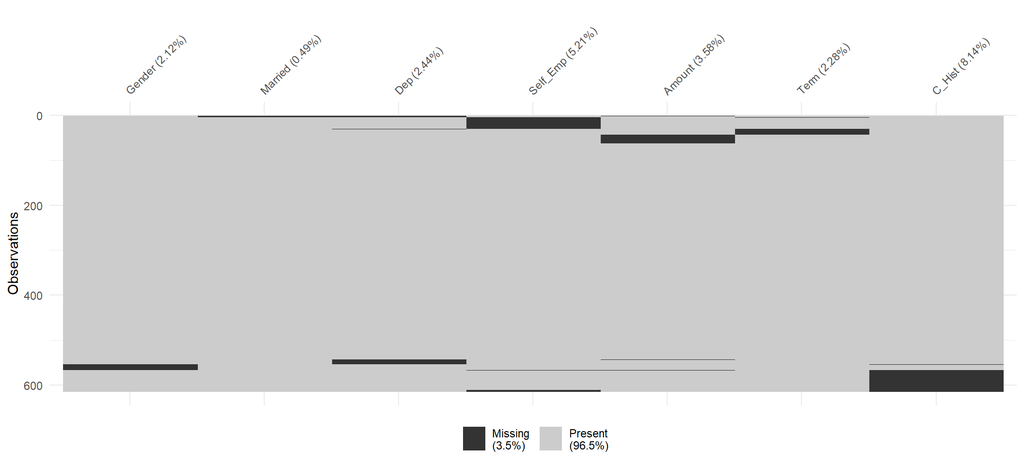

```r
vis_miss(kredyt[,c(1:3,5,8:10)], cluster = T)
```

Można zauważyć, że jak nie ma informacji o tym czy jest ktoś w związku małżeńskim to nie ma także informacji o liczbie podopiecznych - niewiadomo czy w związku małżeńskim = niewiadomo czy ma dzieci, choć nie jest to reguła. Najwięcej osób nie posiada informacji o spełnieniu wytycznych historii kredytowej - 8.14% i o tym czy prowadzi własną działalność - 5.21%. Widać także, że obserwacje mają maksymalnie trzy brakujące wartości.

## 2.2 Outliery

Poniższe boxploty obrazują jak prezentują się outliery w rozważanym zbiorze danych.

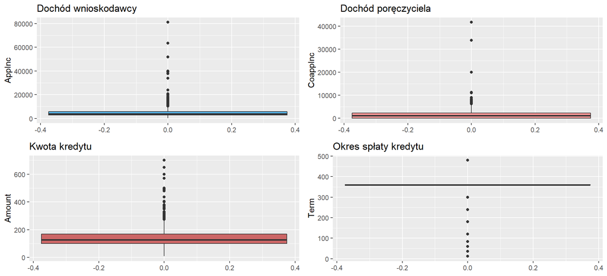

Zmienna przedstawiająca okres spłaty kredytu ma ponad 75% obserwacji o wartości 360, z tego względu każda inna wartość jest traktowana jako wartość odstająca. Nie zostaną one usunięte, a jeśli okaże się, że zmienna `Term` nie ma silnej mocy dyskryminacyjnej to zostanie ona wykluczona z modelu. W przypadku pozostałych zmiennych, w których występuje problem outlierów, wartości odstające zostaną usunięte, a w drugim przypadku zamienione na NA i zaprognozowane.

# 3 Część właściwa badania

## 3.1 Usunięcie outlierów

W tym punkcie zostaną usunięte wszystkie wartości ze zmiennych `AppInc`, `CoappInc` oraz `Amount`, które mogłyby wprowadzać jakiekolwiek zakłocenia w zbiorze.

```r
kredyt <- kredyt[-which(kredyt$AppInc>=10000),]
kredyt <- kredyt[-which(kredyt$CoappInc>=5000),]
kredyt <- kredyt[-which(kredyt$Amount>=250),]
```

### 3.1.1 Usunięcie brakujących wartości

Usunięcie wszystkich obserwacji, które posiadają brakujące wartości.

```r
kredyt <- na.omit(kredyt)
```

Podział zbioru na uczący i testowy za pomocą 10-krotnej walidacji krzyżowej:

```r
set.seed(123)

kredyt<-kredyt[sample(nrow(kredyt)),]

#utworzenie 10 części o jednakowej wielkości
folds <- cut(seq(1,nrow(kredyt)),breaks=10,labels=FALSE)

#10-krotna walidacja krzyżowa
for(i in 1:10){
  #Podział danych na części za pomocą funkcji which()
  testIndexes <- which(folds==i,arr.ind=TRUE)
  test <- kredyt[testIndexes, ]
  train <- kredyt[-testIndexes, ]
}
```

```
##     Gender    Married   Dep               Educ     Self_Emp
##        :  0      :  0    :  0   Graduate    :272      :  0
##  Female: 64   No :129   0:210   Not Graduate: 88   No :318
##  Male  :296   Yes:231   1: 55                      Yes: 42
##                         2: 65
##                         3: 30
##
##      AppInc        CoappInc        Amount            Term
##  Min.   : 150   Min.   :   0   Min.   :  9.00   Min.   : 36.0
##  1st Qu.:2676   1st Qu.:   0   1st Qu.: 96.75   1st Qu.:360.0
##  Median :3595   Median :1036   Median :120.00   Median :360.0
##  Mean   :3999   Mean   :1187   Mean   :122.59   Mean   :342.2
##  3rd Qu.:4824   3rd Qu.:2039   3rd Qu.:150.25   3rd Qu.:360.0
##  Max.   :9963   Max.   :4996   Max.   :246.00   Max.   :480.0
##      C_Hist            Prop_Ar        Status
##  Min.   :0.0000   Rural    :107   Min.   :0.0
##  1st Qu.:1.0000   Semiurban:139   1st Qu.:0.0
##  Median :1.0000   Urban    :114   Median :0.0
##  Mean   :0.8528                   Mean   :0.3
##  3rd Qu.:1.0000                   3rd Qu.:1.0
##  Max.   :1.0000                   Max.   :1.0
```

```
##     Gender   Married  Dep              Educ    Self_Emp     AppInc
##        : 0      : 0    : 0   Graduate    :34      : 0   Min.   :1500
##  Female: 8   No :14   0:27   Not Graduate: 6   No :37   1st Qu.:3081
##  Male  :32   Yes:26   1: 6                     Yes: 3   Median :3602
##                       2: 5                              Mean   :4116
##                       3: 2                              3rd Qu.:4618
##                                                         Max.   :8624
##     CoappInc        Amount           Term           C_Hist
##  Min.   :   0   Min.   : 30.0   Min.   : 84.0   Min.   :0.000
##  1st Qu.:   0   1st Qu.:109.5   1st Qu.:360.0   1st Qu.:1.000
##  Median :1816   Median :125.5   Median :360.0   Median :1.000
##  Mean   :1505   Mean   :127.2   Mean   :345.6   Mean   :0.875
##  3rd Qu.:2437   3rd Qu.:141.8   3rd Qu.:360.0   3rd Qu.:1.000
##  Max.   :4417   Max.   :207.0   Max.   :360.0   Max.   :1.000
##       Prop_Ar       Status
##  Rural    :12   Min.   :0.00
##  Semiurban:20   1st Qu.:0.00
##  Urban    : 8   Median :0.00
##                 Mean   :0.25
##                 3rd Qu.:0.25
##                 Max.   :1.00
```

#### 3.1.1.1 regresja logistyczna

Funkcja używana do budowy modelu regresji logistycznej:

```r
set.seed(123)
logistic_regression <- glm(Status~., family = "binomial", data = train)
```

Funkcja, która za pomocą metody krokowej wstecznej wybiera do modelu tylko te zmienne, które są istotne.

```r
set.seed(123)
logistic_regression_final <- step(logistic_regression, direction = "backward", trace=FALSE, k=3 )
summary(logistic_regression_final)
```

```
##
## Call:
## glm(formula = Status ~ Gender + C_Hist + Prop_Ar, family = "binomial",
##     data = train)
##
## Deviance Residuals:
##     Min       1Q   Median       3Q      Max
## -2.3009  -0.6965  -0.4381   0.3891   2.1869
##
## Coefficients:
##                  Estimate Std. Error z value Pr(>|z|)
## (Intercept)       3.46899    0.61417   5.648 1.62e-08 ***
## GenderMale       -0.92596    0.34201  -2.707  0.00678 **
## C_Hist           -3.83596    0.50865  -7.541 4.65e-14 ***
## Prop_ArSemiurban -1.00228    0.36223  -2.767  0.00566 **
## Prop_ArUrban      0.03049    0.33445   0.091  0.92736
## ---
## Signif. codes:  0 '***' 0.001 '**' 0.01 '*' 0.05 '.' 0.1 ' ' 1
##
## (Dispersion parameter for binomial family taken to be 1)
##
##     Null deviance: 439.82  on 359  degrees of freedom
## Residual deviance: 319.87  on 355  degrees of freedom
## AIC: 329.87
##
## Number of Fisher Scoring iterations: 5
```

Poniżej przedstawione są macierze błędu oraz wykresy krzywej ROC zarówno dla zbioru testowego jak i treningowego.

```
##
## pred_rl_test  0  1
##            0 28  5
##            1  2  5
```

```
##
## pred_rl_train   0   1
##             0 231  48
##             1  21  60
```

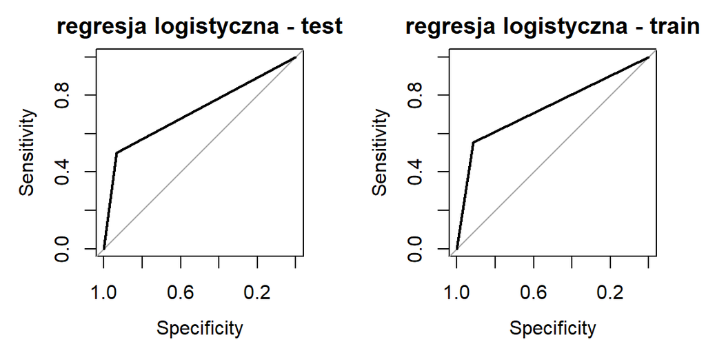

##### 3.1.1.1.1 Wyniki modelu regresji logistycznej

| zbior | metoda | dokladnosc | specyficznosc | czulosc | AUC |
| --- | --- | --- | --- | --- | --- |
| testowy | regresja logistyczna | 0.82 | 0.93 | 0.5 | 0.72 |

| zbior | metoda | dokladnosc | specyficznosc | czulosc | AUC |
| --- | --- | --- | --- | --- | --- |
| treningowy | regresja logistyczna | 0.81 | 0.92 | 0.56 | 0.74 |

Dokładność na zbiorze testowym prezentuje się lepiej niż na zbiorze treningowym i jest to różnica 1% wynikająca z lepszej specyficzności - poprawnym zaklasyfikowaniu tych, którzy otrzymali kredyt. Jeśli chodzi o czułość - poprawną klasyfikację tych, którzy nie otrzymali kredytu, to lepiej wypada zbiór treningowy. Wartość AUC - wartość pola pod krzywą ROC, która wskazuje na przypadkową klasyfikację w przypadku wartości 0.5, jest lepsza na zbiorze trengowym. Ogólnie wyniki predykcji na zbiorze testowym i treningowym nie różnią się znacząco.

#### 3.1.1.2 Random Forest

Funkcja do tworzenia modelu Random Forest na podstawie optymalnej liczby drzew, wybranej dzięki minimalizacji błedu OOB - średniego błędu prognozowania na każdej próbce treningowej $xᵢ$ , wykorzystujący tylko drzewa, które nie miały $ xᵢ$ w próbce bootstrap.

```r
set.seed(123)
oob = c()
for(i in 1:500){
  classifier <-  randomForest(as.factor(Status)~.,data = train,
                              ntree = i)
  oob[i] <- classifier$err.rate[nrow(classifier$err.rate), "OOB"]
}
opt_i <- which.min(oob)
opt_i
```

```
## [1] 76
```

```r
random_Forest <- randomForest::randomForest(as.factor(Status)~.,data = train, ntree = opt_i, keep.forest=TRUE,na.action=na.roughfix)
```

Poniżej przedstawione są macierze błędu oraz wykresy krzywej ROC zarówno dla zbioru testowego jak i treningowego.

```
##
## pred_rF_test  0  1
##            0 29  5
##            1  1  5
```

```
##
## pred_rF_train   0   1
##             0 252   3
##             1   0 105
```

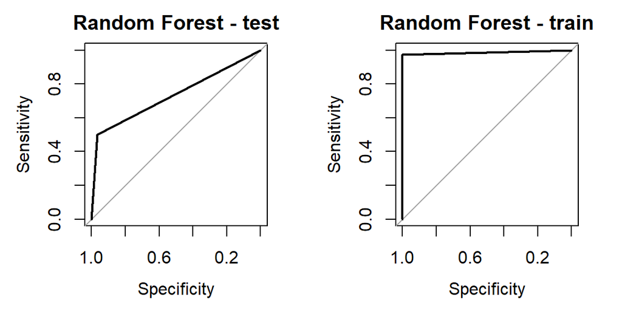

##### 3.1.1.2.1 Wyniki modelu Random Forest

| zbior | metoda | dokladnosc | specyficznosc | czulosc | AUC |
| --- | --- | --- | --- | --- | --- |
| testowy | Random Forest | 0.85 | 0.97 | 0.5 | 0.73 |

| zbior | metoda | dokladnosc | specyficznosc | czulosc | AUC |
| --- | --- | --- | --- | --- | --- |
| treningowy | Random Forest | 0.99 | 1 | 0.97 | 0.99 |

Wyniki modelu na zbiorze treningowym są niemalże idealne - wartość ACC i AUC mają 99%, specyficzność jest równa 1, a czułość 0.97. Tak dobre wyniki świadczą o przeuczeniu modelu. Może to wynikać ze zbyt małej próbki. Zbiór testowy wykazuje się bardzo dobrą specyficznością - poprawną klasyfikacją tych, którzy otrzymali kredyt. Natomiast patrząc na czułość możnaby uznać, że klasyfikacja tych, którzy nie otrzymali kredyu jest przypadkowa.

#### 3.1.1.3 Bagging

Funkcja użyta do budowy modelu baggingu:

```r
set.seed(123)
bagging <- ipred::bagging(Status~., data=train, nbag =100)
```

Poniżej przedstawione są macierze błędu oraz wykresy krzywej ROC zarówno dla zbioru testowego jak i treningowego.

```
##
## pred_bag_test  0  1
##             0 28  5
##             1  2  5
```

```
##
## pred_bag_train   0   1
##              0 232  14
##              1  20  94
```

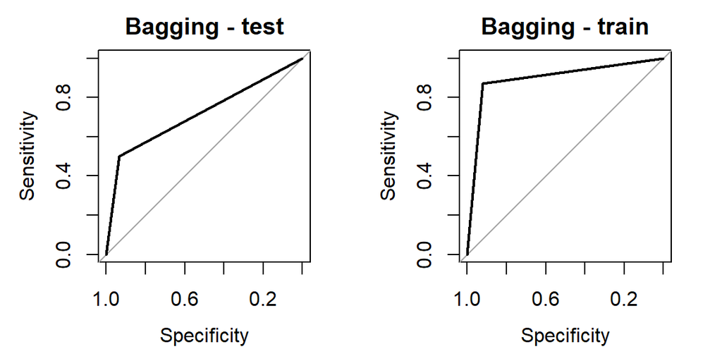

##### 3.1.1.3.1 Wyniki modelu Bagging

| zbior | metoda | dokladnosc | specyficznosc | czulosc | AUC |
| --- | --- | --- | --- | --- | --- |
| testowy | Bagging | 0.82 | 0.93 | 0.5 | 0.72 |

| zbior | metoda | dokladnosc | specyficznosc | czulosc | AUC |
| --- | --- | --- | --- | --- | --- |
| treningowy | Bagging | 0.91 | 0.92 | 0.87 | 0.9 |

#### 3.1.1.4 Boosting

Funkcja użyta do budowy modelu boostingu.

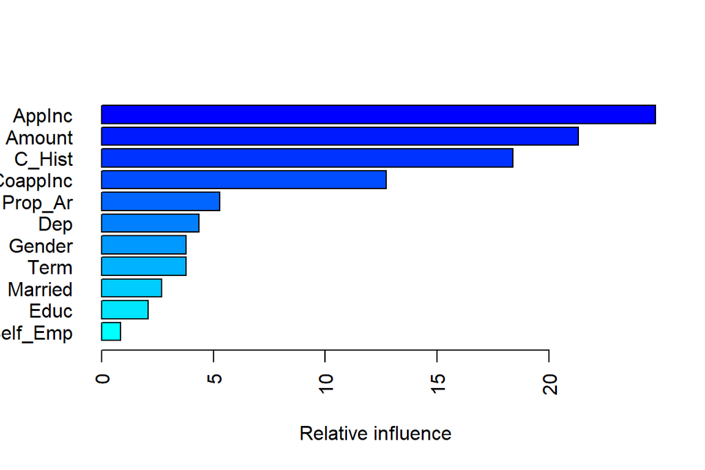

```r
set.seed(123)
boosting <- gbm::gbm(Status~.,data=train, n.trees = 600)
summary(boosting, las = 2)
```

Przy użyciu 600 drzew najbardziej istotnymi zmiennymi są: `AppInc`, `Amount` oraz `C_Hist`. Jedynie zmienna `C_Hist` pokrywa się z wynikiem regresji logistycznej, choć nie jest to najsilniej dyskryminacyjna zmienna w przypadku boostingu.

Poniżej przedstawione są macierze błędu oraz wykresy krzywej ROC zarówno dla zbioru testowego jak i treningowego.

```
##
## pred_boo_test  0  1
##             0 29  4
##             1  1  6
```

```
##
## pred_boo_train   0   1
##              0 222  17
##              1  30  91
```

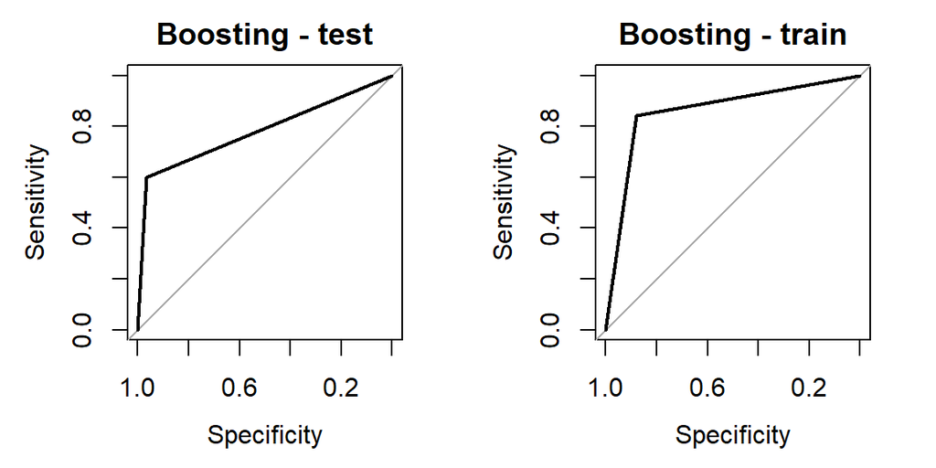

##### 3.1.1.4.1 Wyniki modelu Boosting

| zbior | metoda | dokladnosc | specyficznosc | czulosc | AUC |
| --- | --- | --- | --- | --- | --- |
| testowy | Boosting | 0.88 | 0.97 | 0.6 | 0.78 |

| zbior | metoda | dokladnosc | specyficznosc | czulosc | AUC |
| --- | --- | --- | --- | --- | --- |
| treningowy | Boosting | 0.87 | 0.88 | 0.84 | 0.86 |

Zbiór treningowy choć ma mniejsze ACC, to w ogólnym rozrachunku wypada lepiej, gdyż ma i czułość i specyficzność na dobrym poziomie, czego nie można powiedzieć o zbiorze testowym. Jego specyficzność jest duża, natomiast czułość to tylko 60%, choć biorąc pod uwagę wyniki poprzednich modeli to jest to najlepsza wartość.

#### 3.1.1.5 Naive Bayes

Funkcja użyta do budowy modelu Naive Bayes.

```r
set.seed(123)
naive <- naiveBayes(as.factor(Status)~.,data=train)
```

Poniżej przedstawione są macierze błędu oraz wykresy krzywej ROC zarówno dla zbioru testowego jak i treningowego.

```
##
## pred_nb_test  0  1
##            0 29  5
##            1  1  5
```

```
##
## pred_nb_train   0   1
##             0 244  57
##             1   8  51
```

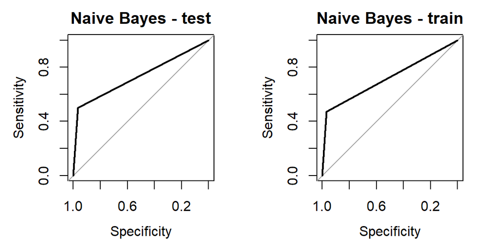

##### 3.1.1.5.1 Wyniki modelu Naive Bayes

| zbior | metoda | dokladnosc | specyficznosc | czulosc | AUC |
| --- | --- | --- | --- | --- | --- |
| testowy | Naive Bayes | 0.85 | 0.97 | 0.5 | 0.73 |

| zbior | metoda | dokladnosc | specyficznosc | czulosc | AUC |
| --- | --- | --- | --- | --- | --- |
| treningowy | Naive Bayes | 0.82 | 0.97 | 0.47 | 0.72 |

Naive Bayes na zbiorze testowym i treningowym ma taką samą wartość specyficzności, natomiast na zbiorze treningowym czułość jest mniejsza niż 50%, co oznacza, że model jest bezużyteczy - losowa klasyfikacja.

Usunięcie wszystkich obserwacji, które zawierają brakujące wartości oraz outlierów nie daje zadowalających wyników, najprawdopodobniej z tego względu, że typ brakujących wartości nie jest typem MCAR - braki w obserwacjach są kompletnie przypadkowe. Prawdopodobnie jest to typ MAR lub MNAR, gdzie brak wartości może zależeć od innej zmiennej lub od zjawiska niezbadanego - na przykład osoby ankietowane, które zarabiają dużo mogą nie podawać wysokości swoich zarobków. Usunięcie takiego typu zmiennych zwyczajnie powoduje utratę ważnych informacji.

### 3.1.2 Prognozowanie brakujących wartości za pomocą k-najbliższych sąsiadów

Zarówno regresja logistyczna jak i Boosting nie wykazaly istotnego wpływu zmiennej `Term`, więc zostanie ona usunięta z modelu, by nie zakłócać wyników wartościami odstającymi.

Poniżej zostaną przedstawione wyniki modeli po imputacji wartości brakujących za pomocą metody 6-najbliższych sąsiadów.

```r
kredyt <- VIM::kNN(kredyt, k = 6)
kredyt <- subset(kredyt, select = Gender:Status)
```

#### 3.1.2.1 regresja logistyczna

Poniżej przedstawiony jest najlepszy model regresji logistycznej po wyborze metodą krokową wsteczną.

```
##
## Call:
## glm(formula = Status ~ AppInc + CoappInc + Amount + C_Hist +
##     Prop_Ar, family = "binomial", data = train)
##
## Deviance Residuals:
##     Min       1Q   Median       3Q      Max
## -2.7390  -0.6754  -0.4667   0.2695   2.4887
##
## Coefficients:
##                    Estimate Std. Error z value Pr(>|z|)
## (Intercept)       3.5116499  0.7407218   4.741 2.13e-06 ***
## AppInc           -0.0002356  0.0001116  -2.112  0.03469 *
## CoappInc         -0.0004348  0.0001438  -3.023  0.00250 **
## Amount            0.0105703  0.0045682   2.314  0.02067 *
## C_Hist           -4.5689758  0.5495587  -8.314  < 2e-16 ***
## Prop_ArSemiurban -1.1354060  0.3473003  -3.269  0.00108 **
## Prop_ArUrban     -0.0293434  0.3085781  -0.095  0.92424
## ---
## Signif. codes:  0 '***' 0.001 '**' 0.01 '*' 0.05 '.' 0.1 ' ' 1
##
## (Dispersion parameter for binomial family taken to be 1)
##
##     Null deviance: 560.29  on 459  degrees of freedom
## Residual deviance: 373.66  on 453  degrees of freedom
## AIC: 387.66
##
## Number of Fisher Scoring iterations: 5
```

W skład finalnego modelu weszły takie zmienne jak: `AppInc`, `CoappInc`, `Amount`, `Prop_Ar` oraz `C_Hist`, która ponownie jest najsilniej dyskryminacyjną zmienną.

Poniżej przedstawione są macierze błędu oraz wykresy krzywej ROC zarówno dla zbioru testowego jak i treningowego.

```
##
## pred_rl_test  0  1
##            0 31  8
##            1  3 10
```

```
##
## pred_rl_train   0   1
##             0 297  52
##             1  26  85
```

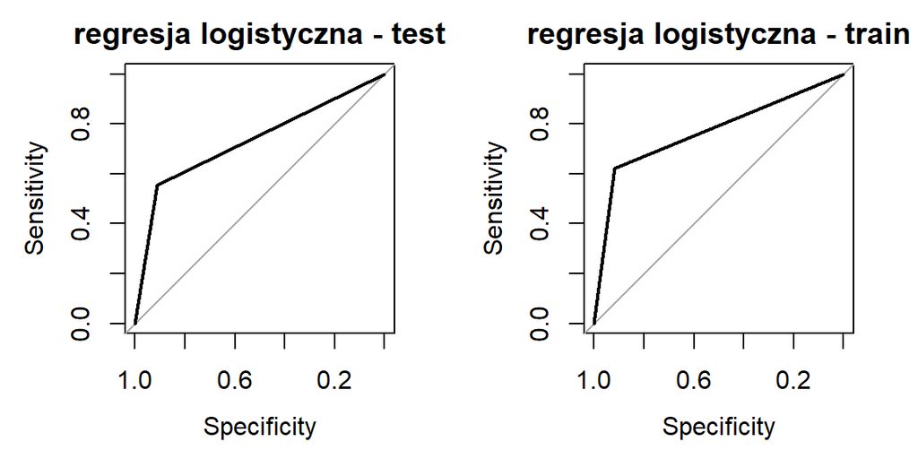

##### 3.1.2.1.1 Wyniki modelu regresji logistycznej

| zbior | metoda | dokladnosc | specyficznosc | czulosc | AUC |
| --- | --- | --- | --- | --- | --- |
| testowy | regresja logistyczna | 0.79 | 0.91 | 0.56 | 0.73 |

| zbior | metoda | dokladnosc | specyficznosc | czulosc | AUC |
| --- | --- | --- | --- | --- | --- |
| treningowy | regresja logistyczna | 0.83 | 0.92 | 0.62 | 0.77 |

Wynik czułości na zbiorze treningowym jest niska, gdyż wynosi 62%, na biorze testowym jest to 56%, czyli też bardzo mało. Oba zbiory mają wysoką wartość specyficzności - ponad 90%. Nie jest to jednak dobry model.

#### 3.1.2.2 Random Forest

Poniżej przedstawione są macierze błędu oraz wykresy krzywej ROC zarówno dla zbioru testowego jak i treningowego.

```
##
## pred_rF_test  0  1
##            0 33  8
##            1  1 10
```

```
##
## pred_rF_train   0   1
##             0 323   8
##             1   0 129
```

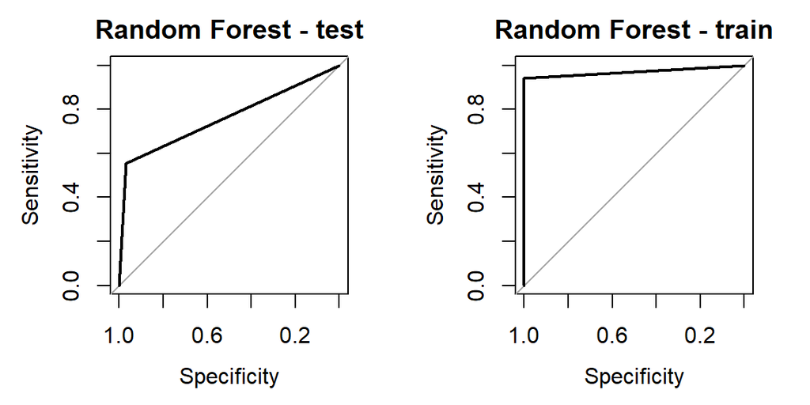

##### 3.1.2.2.1 Wyniki modelu Random Forest

| zbior | metoda | dokladnosc | specyficznosc | czulosc | AUC |
| --- | --- | --- | --- | --- | --- |
| testowy | Random Forest | 0.83 | 0.97 | 0.56 | 0.76 |

| zbior | metoda | dokladnosc | specyficznosc | czulosc | AUC |
| --- | --- | --- | --- | --- | --- |
| treningowy | Random Forest | 0.98 | 1 | 0.94 | 0.97 |

Zbiór treningowy wykazuje przeuczenie, ze względu na bardzo wysokie wyniki - prawie 100% dokładność. Zbiór testowy wypada gorzej ze względu na niską wartość czułości.

#### 3.1.2.3 Bagging

Poniżej przedstawione są macierze błędu oraz wykresy krzywej ROC zarówno dla zbioru testowego jak i treningowego.

```
##
## pred_bag_test  0  1
##             0 31  8
##             1  3 10
```

```
##
## pred_bag_train   0   1
##              0 307  25
##              1  16 112
```

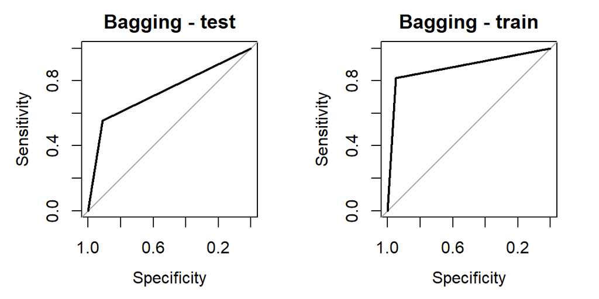

##### 3.1.2.3.1 Wyniki modelu baggingu

| zbior | metoda | dokladnosc | specyficznosc | czulosc | AUC |
| --- | --- | --- | --- | --- | --- |
| testowy | Bagging | 0.79 | 0.91 | 0.56 | 0.73 |

| zbior | metoda | dokladnosc | specyficznosc | czulosc | AUC |
| --- | --- | --- | --- | --- | --- |
| treningowy | Bagging | 0.91 | 0.95 | 0.82 | 0.88 |

Zbiór treningowy ma wartość AUC bliską 90%, wartość specyficzności to 95%, czułość natomiast jest na poziomie 82%, co biorąc pod uwagę inne modele poza Random Forest jest bardzo dobrym wynikiem. Zbiór testowy ma wysokość specyficzność, natomiast jego czułość to 56%.

#### 3.1.2.4 Boosting

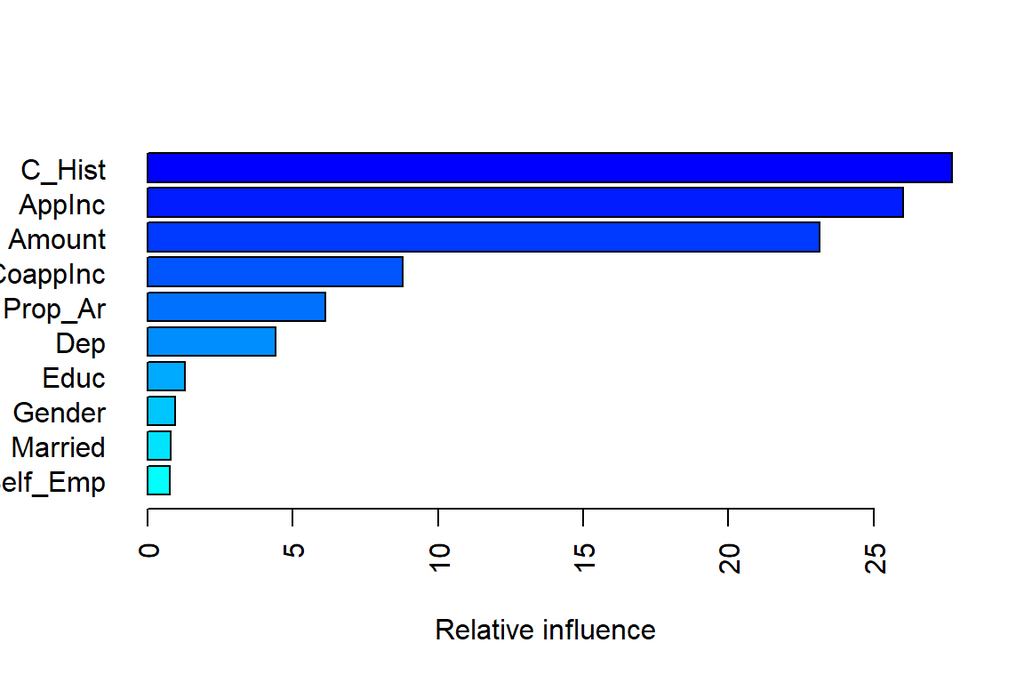

Zmiennymi, które najsilniej dyskryminują są: `C_Hist`, `AppInc` oraz `Amount`.

Poniżej przedstawione są macierze błędu oraz wykresy krzywej ROC zarówno dla zbioru testowego jak i treningowego.

```
##
## pred_boo_test  0  1
##             0 29  8
##             1  5 10
```

```
##
## pred_boo_train   0   1
##              0 303  50
##              1  20  87
```

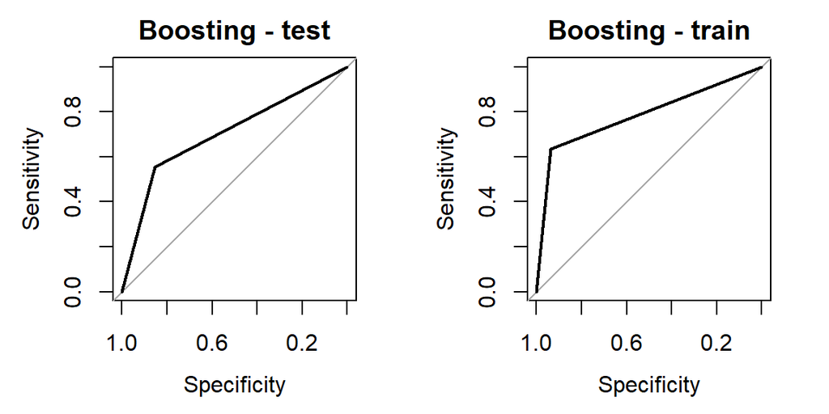

##### 3.1.2.4.1 Wyniki modelu boostingu

| zbior | metoda | dokladnosc | specyficznosc | czulosc | AUC |
| --- | --- | --- | --- | --- | --- |
| testowy | Boosting | 0.75 | 0.85 | 0.56 | 0.7 |

| zbior | metoda | dokladnosc | specyficznosc | czulosc | AUC |
| --- | --- | --- | --- | --- | --- |
| treningowy | Boosting | 0.85 | 0.94 | 0.64 | 0.79 |

Czułość zarówno na zbiorze treningowym jak i testowym przyjmuje w dalszym ciągu niskie wartości - na zbiorze treningowym jest to 64%, natomiast na zbiorze testowym tylko 56%. Specyficzność na zbiorze testowym jest gorsza w porównaniu do innych modeli.

#### 3.1.2.5 Naive Bayes

Poniżej przedstawione są macierze błędu oraz wykresy krzywej ROC zarówno dla zbioru testowego jak i treningowego.

```
##
## pred_nb_test  0  1
##            0 33  8
##            1  1 10
```

```
##
## pred_nb_train   0   1
##             0 319  70
##             1   4  67
```

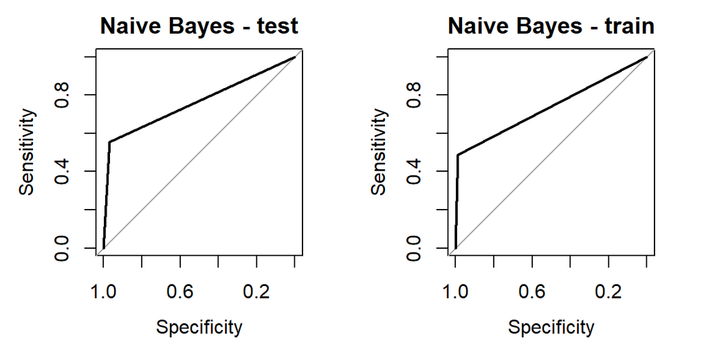

##### 3.1.2.5.1 Wyniki modelu Naive Bayes

| zbior | metoda | dokladnosc | specyficznosc | czulosc | AUC |
| --- | --- | --- | --- | --- | --- |
| testowy | Naive Bayes | 0.83 | 0.97 | 0.56 | 0.76 |

| zbior | metoda | dokladnosc | specyficznosc | czulosc | AUC |
| --- | --- | --- | --- | --- | --- |
| treningowy | Naive Bayes | 0.84 | 0.99 | 0.49 | 0.74 |

Wyniki na zbiorze testowym i treningowym są bardzo zbliżone, zbiór treningowy wykazuje się lepszą specyficznością, testowy natomiast ma wyższą czułość - lepiej rozpoznaje tych, którzy nie otrzymali kredytu.

## 3.2 Zamiana outlierów na NA

W tym punkcie wszystkie wartości ze zmiennych `AppInc`, `CoappInc` oraz `Amount`, które mogłyby wprowadzać jakiekolwiek zakłocenia w zbiorze zostaną zamienione na NA i ich wartości zostaną zaprognozowane za pomocą metody 6-najbliższych sąsiadów.

```r
kredyt[which(kredyt$AppInc>=10000),6] <- NA
kredyt[which(kredyt$CoappInc>=5000),7] <- NA
kredyt[which(kredyt$Amount>=250),8] <- NA
```

### 3.2.1 Prognozowanie brakujących wartości za pomocą k-najbliższych sąsiadów

Brakujące wartości w zbiorze zostaną imputowane za pomocą metody 6-najbliższych sąsiadów. Zmienna `Term` nie będzie uwzględniana w modelach.

#### 3.2.1.1 regresja logistyczna

Poniżej przedstawiony jest najlepszy model regresji logistycznej po wyborze metodą krokową wsteczną.

```
##
## Call:
## glm(formula = Status ~ AppInc + CoappInc + Amount + C_Hist +
##     Prop_Ar, family = "binomial", data = train)
##
## Deviance Residuals:
##     Min       1Q   Median       3Q      Max
## -2.5838  -0.7014  -0.5319   0.3464   2.4706
##
## Coefficients:
##                    Estimate Std. Error z value Pr(>|z|)
## (Intercept)       3.411e+00  6.281e-01   5.431 5.61e-08 ***
## AppInc           -1.805e-04  8.079e-05  -2.234  0.02551 *
## CoappInc         -3.049e-04  1.102e-04  -2.765  0.00569 **
## Amount            5.986e-03  3.436e-03   1.742  0.08152 .
## C_Hist           -4.141e+00  4.485e-01  -9.232  < 2e-16 ***
## Prop_ArSemiurban -8.812e-01  2.916e-01  -3.022  0.00251 **
## Prop_ArUrban     -1.832e-01  2.749e-01  -0.666  0.50515
## ---
## Signif. codes:  0 '***' 0.001 '**' 0.01 '*' 0.05 '.' 0.1 ' ' 1
##
## (Dispersion parameter for binomial family taken to be 1)
##
##     Null deviance: 684.89  on 551  degrees of freedom
## Residual deviance: 485.39  on 545  degrees of freedom
## AIC: 499.39
##
## Number of Fisher Scoring iterations: 5
```

W skład finalnego modelu weszły takie zmienne jak: `AppInc`, `CoappInc`, `Amount`, `Prop_Ar` oraz `C_Hist`, która ponownie jest najsilniej dyskryminacyjną zmienną.

Poniżej przedstawione są macierze błędu oraz wykresy krzywej ROC zarówno dla zbioru testowego jak i treningowego.

```
##
## pred_rl_test  0  1
##            0 41  7
##            1  1 13
```

```
##
## pred_rl_train   0   1
##             0 351  76
##             1  29  96
```

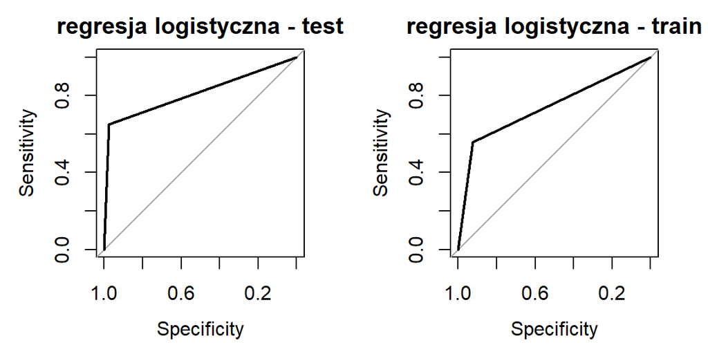

##### 3.2.1.1.1 Wyniki modelu regresji logistycznej

| zbior | metoda | dokladnosc | specyficznosc | czulosc | AUC |
| --- | --- | --- | --- | --- | --- |
| testowy | regresja logistyczna | 0.87 | 0.98 | 0.65 | 0.81 |

| zbior | metoda | dokladnosc | specyficznosc | czulosc | AUC |
| --- | --- | --- | --- | --- | --- |
| treningowy | regresja logistyczna | 0.81 | 0.92 | 0.56 | 0.74 |

Wyniki regresji logistycznej na zbiorze testowym są o wiele lepsze niż na zbiorze treningowym, co jest zaskakujące, gdyż wyniki na zbiorze testowym powinny być niższe, ze względu na to, że są to obserwacje wcześniej nieznane. Jest bardzo niska czułość na zbiorze treningowym - 56%, przy czym na zbiorze testowym wynosi ona 65%. Specyficzność też jest znacznie większa. Wartość AUC - pole pod krzywą ROC na zbiorze testowym wynosi 81%, na zbiorze trengowym zaś 74%.

#### 3.2.1.2 Random Forest

Poniżej przedstawione są macierze błędu oraz wykresy krzywej ROC zarówno dla zbioru testowego jak i treningowego.

```
##
## pred_rF_test  0  1
##            0 41 11
##            1  1  9
```

```
##
## pred_rF_train   0   1
##             0 380   3
##             1   0 169
```

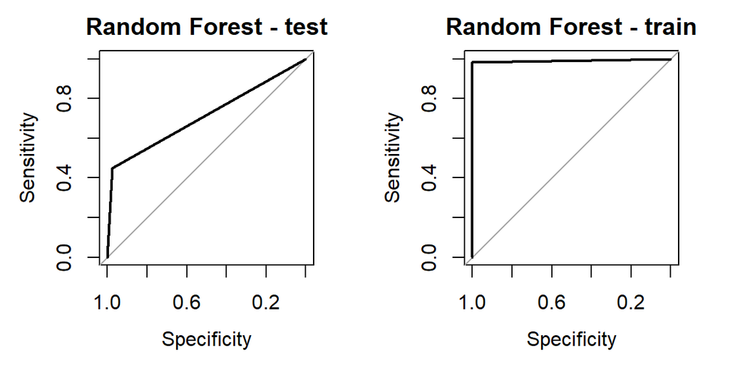

##### 3.2.1.2.1 Wyniki modelu Random Forest

| zbior | metoda | dokladnosc | specyficznosc | czulosc | AUC |
| --- | --- | --- | --- | --- | --- |
| testowy | Random Forest | 0.81 | 0.98 | 0.45 | 0.71 |

| zbior | metoda | dokladnosc | specyficznosc | czulosc | AUC |
| --- | --- | --- | --- | --- | --- |
| treningowy | Random Forest | 0.99 | 1 | 0.98 | 0.99 |

Model Random Forest również w tej sytuacji wydaje się być przeuczony. Ma bardzo wysokie wartości na zbiorze treningowym. Jeśli chodzi o zbiór testowy, wartość czułości na zbiorze testowym jest mniejsza niż 50%, co oznacza, że model jest bezużyteczny.

#### 3.2.1.3 Bagging

Poniżej przedstawione są macierze błędu oraz wykresy krzywej ROC zarówno dla zbioru testowego jak i treningowego.

```
##
## pred_bag_test  0  1
##             0 35  9
##             1  7 11
```

```
##
## pred_bag_train   0   1
##              0 353  28
##              1  27 144
```

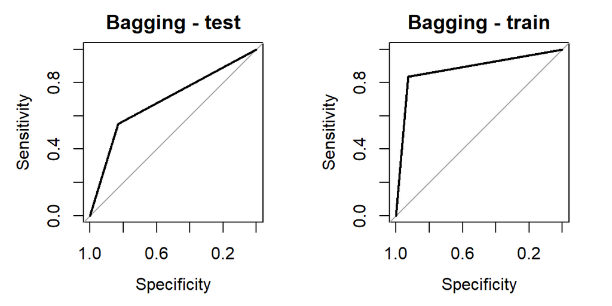

##### 3.2.1.3.1 Wyniki modelu baggingu

| zbior | metoda | dokladnosc | specyficznosc | czulosc | AUC |
| --- | --- | --- | --- | --- | --- |
| testowy | Bagging | 0.74 | 0.83 | 0.55 | 0.69 |

| zbior | metoda | dokladnosc | specyficznosc | czulosc | AUC |
| --- | --- | --- | --- | --- | --- |
| treningowy | Bagging | 0.9 | 0.93 | 0.84 | 0.88 |

Model baggingu na zbiorze treningowym wypada dobrze, natomiast w przypadku zbioru testowego pojawia się taki sam problem jak w innych modelach - zzbyt niska wartość czułości.

#### 3.2.1.4 Boosting

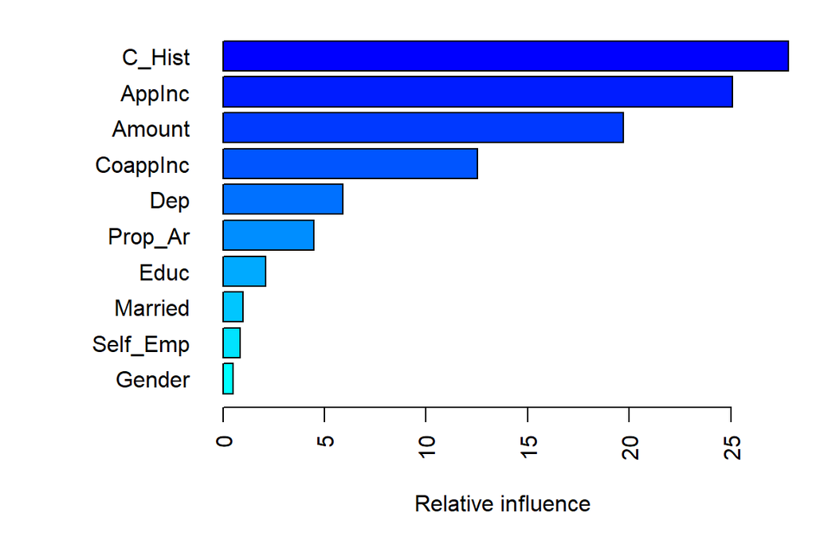

Zmiennymi, które najsilniej dyskryminuje są: `C_Hist`, `AppInc` oraz `Amount`.

Poniżej przedstawione są macierze błędu oraz wykresy krzywej ROC zarówno dla zbioru testowego jak i treningowego.

```
##
## pred_boo_test  0  1
##             0 36  9
##             1  6 11
```

```
##
## pred_boo_train   0   1
##              0 338  57
##              1  42 115
```

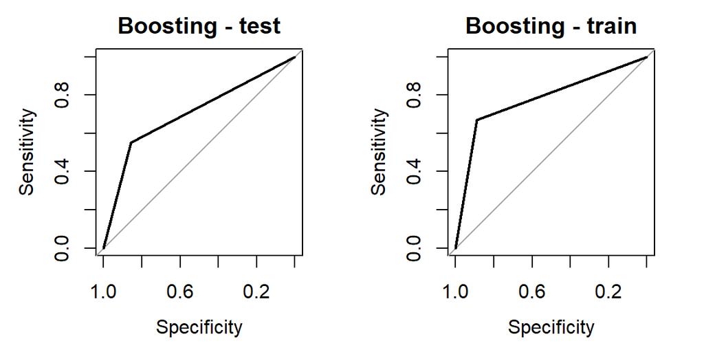

##### 3.2.1.4.1 Wyniki modelu boostingu

| zbior | metoda | dokladnosc | specyficznosc | czulosc | AUC |
| --- | --- | --- | --- | --- | --- |
| testowy | Boosting | 0.76 | 0.86 | 0.55 | 0.7 |

| zbior | metoda | dokladnosc | specyficznosc | czulosc | AUC |
| --- | --- | --- | --- | --- | --- |
| treningowy | Boosting | 0.82 | 0.89 | 0.67 | 0.78 |

Zbiór trengowy wykazuje się 82% dokładnością, natomiast jego czułość - 67% jest niezadowalająca. W zbiorze testowym, występuje problem niskiej czułości. Model jest słaby.

#### 3.2.1.5 Naive Bayes

Poniżej przedstawione są macierze błędu oraz wykresy krzywej ROC zarówno dla zbioru testowego jak i treningowego.

```
##
## pred_nb_test  0  1
##            0 41 11
##            1  1  9
```

```
##
## pred_nb_train   0   1
##             0 374  91
##             1   6  81
```

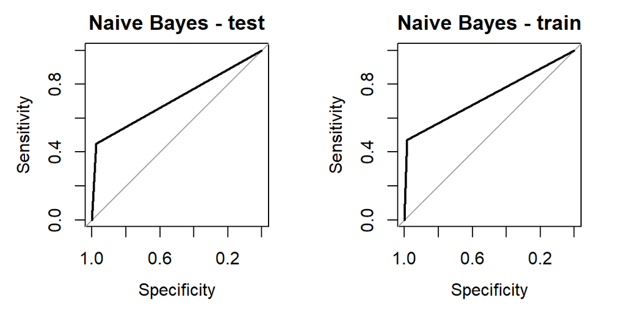

##### 3.2.1.5.1 Wyniki modelu Naive Bayes

| zbior | metoda | dokladnosc | specyficznosc | czulosc | AUC |
| --- | --- | --- | --- | --- | --- |
| testowy | Naive Bayes | 0.81 | 0.98 | 0.45 | 0.71 |

| zbior | metoda | dokladnosc | specyficznosc | czulosc | AUC |
| --- | --- | --- | --- | --- | --- |
| treningowy | Naive Bayes | 0.82 | 0.98 | 0.47 | 0.73 |

Model Naive Bayes jest za słaby, wartości czułości są mniejsze niż 50%.

#### 3.2.1.6 Boosting na podstawie zmiennej `C_Hist`, `AppInc`, `Amount` przy usunięciu NA i outlierów

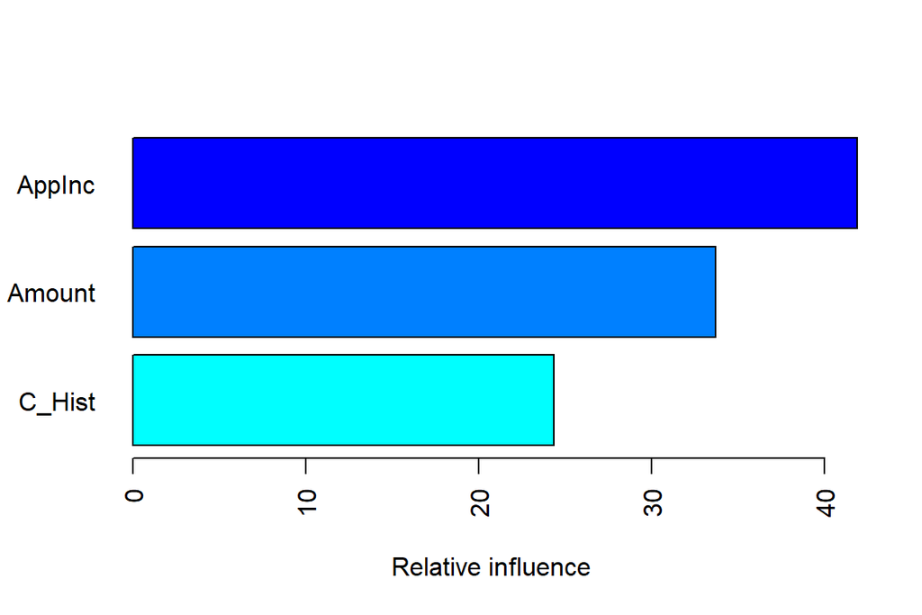

```
##
## pred_boo_test  0  1
##             0 25 10
##             1  5  8
```

```
##
## pred_boo_train   0   1
##              0 274  50
##              1  25  75
```

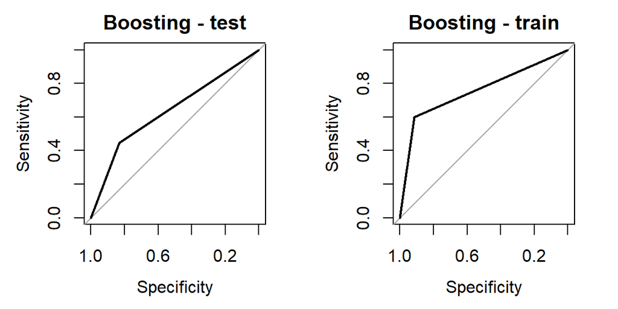

| zbior | metoda | dokladnosc | specyficznosc | czulosc | AUC |
| --- | --- | --- | --- | --- | --- |
| testowy | Boosting | 0.69 | 0.83 | 0.44 | 0.64 |

| zbior | metoda | dokladnosc | specyficznosc | czulosc | AUC |
| --- | --- | --- | --- | --- | --- |
| treningowy | Boosting | 0.82 | 0.92 | 0.6 | 0.76 |

Po zostawieniu tylko 3 najistotniejszych zmiennych w modelu Boosting wyniki się nie poprawiły, a nawet pogorszyły. Czułość na zbiorze testowym to 44% co jest fatalnym wynikiem.

# 4 Podsumowanie